# Soc723 - TE Chapter 07

Turgut Keskintürk

2023-02-11

Hello there! Let’s start our exercises for Huntington-Klein’s *The Effect*, Chapter 7.

## Q1

Here are the responses to the questions:

1. This is **true**. A nice causal effect on viewership is the existence of celebrities.
2. This is **false**. The diagram should include just one variable (e.g., `Evening`), with those values as responses.
3. This is **false**. The fact that we cannot measure something is not a reason for not including it.
4. This is **false**. The information is irrelevant for the DAG.

## Q2

OK, here is the DAG with the features described in the question:

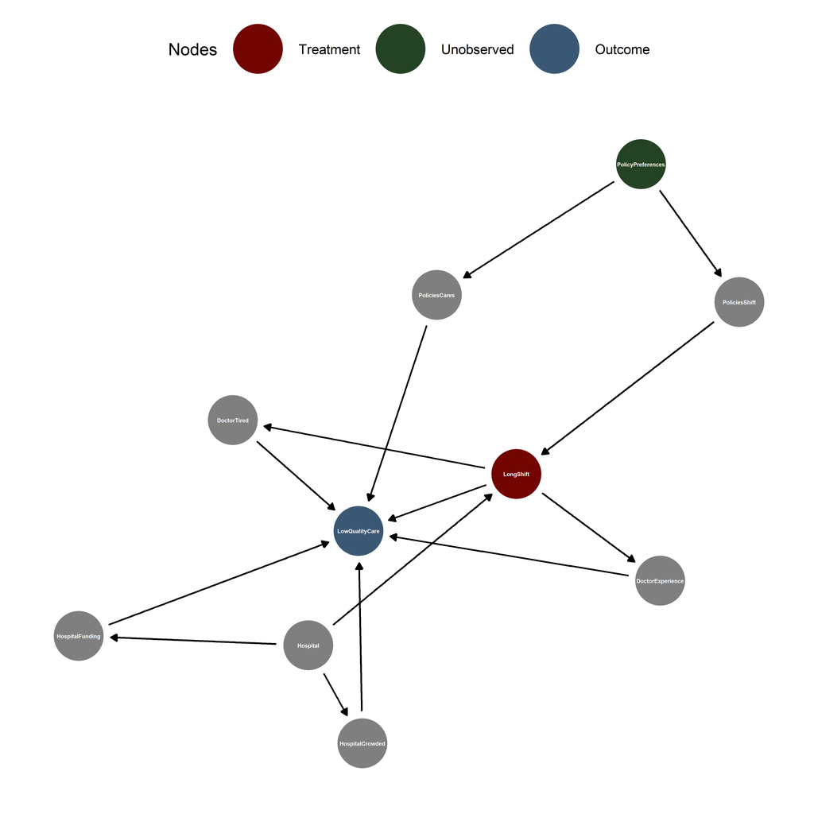

```r
dag <- dagitty(
  "
  dag
  {
  LongShift [exposure]
  LowQualityCare [outcome]
  PolicyPreferences [unobserved]
  LongShift -> LowQualityCare
  LongShift -> DoctorTired
  LongShift -> DoctorExperience
  DoctorTired -> LowQualityCare
  DoctorExperience -> LowQualityCare
  Hospital -> LongShift
  Hospital -> HospitalFunding
  Hospital -> HospitalCrowded
  HospitalFunding -> LowQualityCare
  HospitalCrowded -> LowQualityCare
  PoliciesShift -> LongShift
  PoliciesCares -> LowQualityCare
  PolicyPreferences -> PoliciesShift
  PolicyPreferences -> PoliciesCares
  }
  "
)

set.seed(11235)
ggdag_status(dag, text_col = "white", text_size = 1.4) +
  scale_color_manual(values = c("#720500", "#244224", "#3A5874"),
                     labels = c("Treatment", "Unobserved", "Outcome")) +
  labs(color = "Nodes") +
  theme_dag(legend.position = "top")
```

## Q3

Here are the responses to the questions:

1. The **treatment** is `Funding`, while the **outcome** is `Achievement`.
2. Here are some relevant variables (wanted to keep it short, sorry but also not sorry): `GeographicRegion`, `StudentSES` and `LaggedFunding`. Let us assume that all of these variables can be observed.
3. Here are the shared variables: `GeographicRegion` and `LaggedFunding`.
4. These are *confounders*, so we want to make sure they stay in the DAG and will be adjusted for later.
5. Here is the causal diagram:

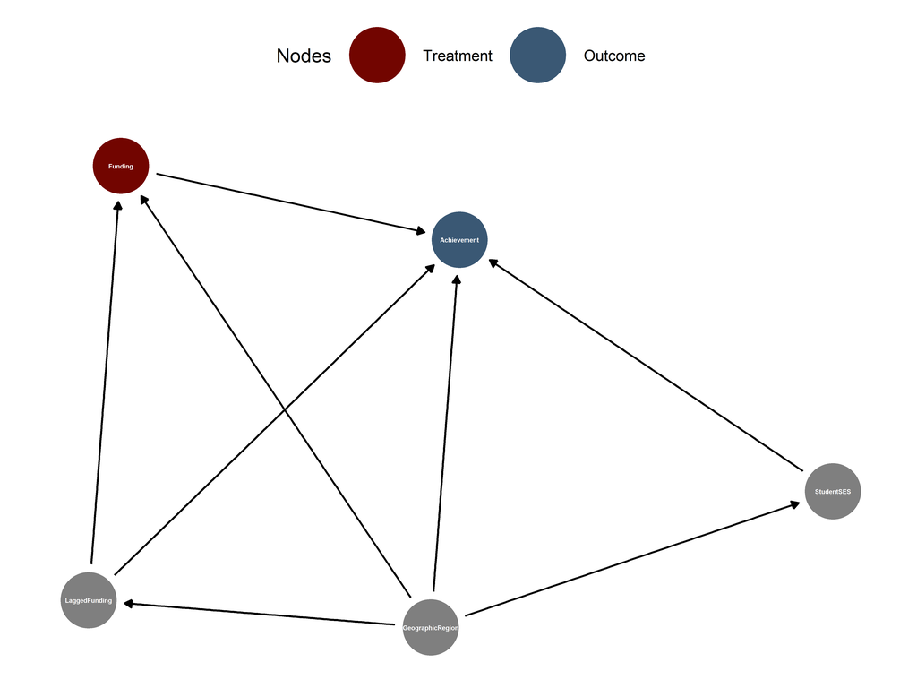

```r
dag <- dagitty(
  "
  dag
  {
  Funding [exposure]
  Achievement [outcome]
  Funding->Achievement
  GeographicRegion->Funding
  GeographicRegion->Achievement
  StudentSES->Achievement
  GeographicRegion->StudentSES
  LaggedFunding->Funding
  LaggedFunding->Achievement
  GeographicRegion->LaggedFunding
  }
  "
)

set.seed(11235)
ggdag_status(dag, text_col = "white", text_size = 1.4) +
  scale_color_manual(values = c("#720500", "#3A5874"),
                     labels = c("Treatment", "Outcome")) +
  labs(color = "Nodes") +
  theme_dag(legend.position = "top")
```

6. OK, it seems that the inclusion of `StudentSES` is not important to explore the causal effect, as conditioning on others is enough.

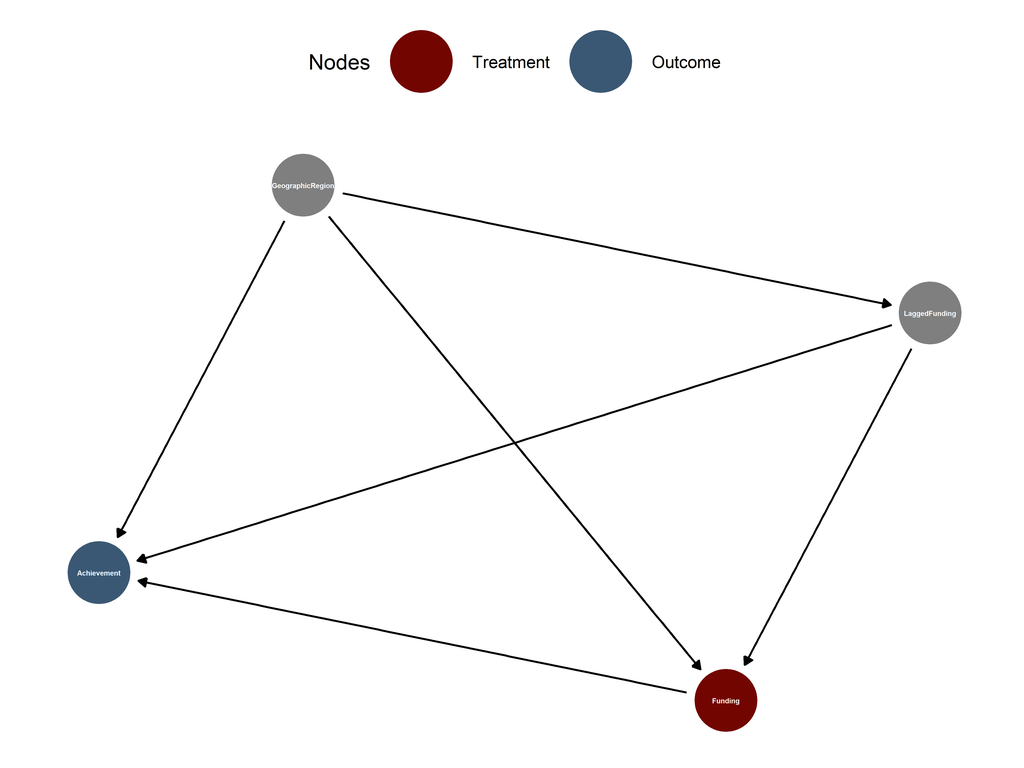

```r
dag <- dagitty(
  "
  dag
  {
  Funding [exposure]
  Achievement [outcome]
  Funding->Achievement
  GeographicRegion->Funding
  GeographicRegion->Achievement
  LaggedFunding->Funding
  LaggedFunding->Achievement
  GeographicRegion->LaggedFunding
  }
  "
)

set.seed(11235)
ggdag_status(dag, text_col = "white", text_size = 1.4) +
  scale_color_manual(values = c("#720500", "#3A5874"),
                     labels = c("Treatment", "Outcome")) +
  labs(color = "Nodes") +
  theme_dag(legend.position = "top")
```

## Q4

Here are the reasons why we do DAG simplifications:

1. **Unimportance**: when the causal effect in question is not important or it is negligible.
2. **Redundancy**: when the variables occupy the same space. For instance, in the example above, we can change `GeographicRegion` to two distinct variables `GeographicSES` and `GeographicSchoolN`, though the implications would remain the same.
3. **Mediators**: if the variable is just a mediator, we can drop it - though I do not agree that we should drop it. Why the hell?
4. **Irrelevance**: As our interest is on the causal path from the treatment to the outcome, we do not need to keep anything that does not affect that relationship - e.g., the `StudentSES` example above, which I dropped.

## Q5

Two ways: (1) adding a time dimension (just subscript everything with $t$) or (2) finding a source of randomness in the variable.

## Q6

Alright, these days I am thinking about the transmission of cultural beliefs from parents to teens.

1. Let’s call the cause `ParentBeliefs` and the outcome `ChildBeliefs`. This is not a “treatment” per se, but hey, it is life!
2. I am going to write 5 variables (of course) for the data generating process: `GeneticBackground` (lol, unobserved), `FamilyEnvironment`, `SchoolEnvironment`, `ParentalEducation`, and `ReligiousAffiliation`.
3. Let’s draw the DAG (with some silly mistakes, so I do not have to wait for 15 minutes):

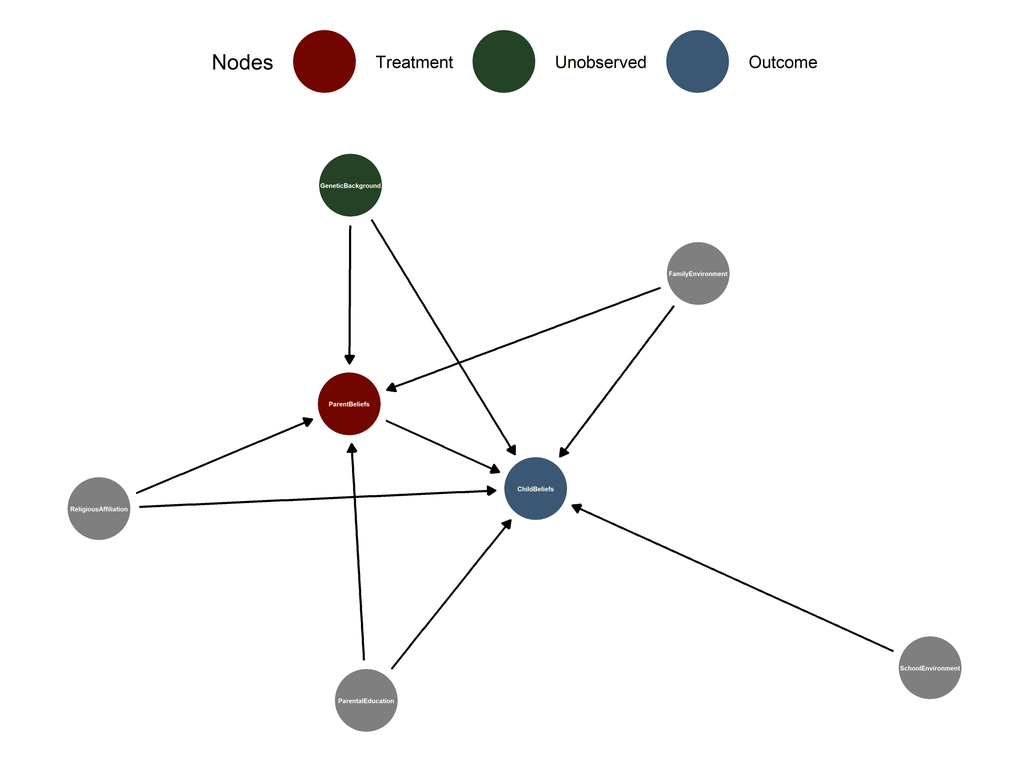

```r
dag <- dagitty(
  "
  dag
  {
  ParentBeliefs [exposure]
  ChildBeliefs [outcome]
  GeneticBackground [unobserved]
  ParentBeliefs -> ChildBeliefs
  ParentBeliefs <- GeneticBackground -> ChildBeliefs
  ParentBeliefs <- FamilyEnvironment -> ChildBeliefs
  ParentBeliefs <- ReligiousAffiliation -> ChildBeliefs
  ParentBeliefs <- ParentalEducation -> ChildBeliefs
  SchoolEnvironment -> ChildBeliefs
  }
  "
)

set.seed(11235)
ggdag_status(dag, text_col = "white", text_size = 1.25) +
  scale_color_manual(values = c("#720500", "#244224", "#3A5874"),
                     labels = c("Treatment", "Unobserved", "Outcome")) +
  labs(color = "Nodes") +
  theme_dag(legend.position = "top")
```

4. OK, I waited for 15 minutes. The bad assumption: `ParentalEducation` should affect `SchoolEnvironment` and `ReligiousAffiliation`, as it is highly probably that parents with differing levels of education are differentiated along these variables.

## Q7

I am going to add the diagram the time dimension, so that it makes some sense:

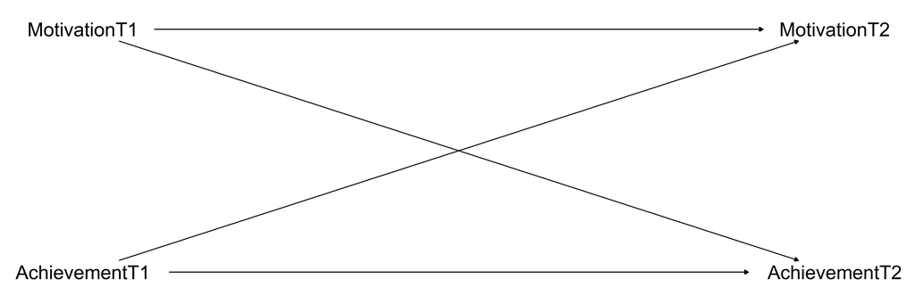

```r
dag <- dagitty(
  "
  dag
  {
  MotivationT1 -> MotivationT2
  AchievementT1 -> AchievementT2
  MotivationT1 -> AchievementT2
  AchievementT1 -> MotivationT2
  }
  "
)

set.seed(11235)
ggdag_classic(dag, layout = "grid") + theme_dag()
```

Thank you!